# Diffusion Dynamics of Clean Energy Technologies in Residential Built Environment

Yohan Min

Updated 2020-05-11

# Abstract

The recent global climate change has led to the development of various clean energy policies and technologies. Clean energy technologies are proven to increase resiliency in response to the interruption from climate change in addition to their economic, health and environmental benefits. However, the following two concerns have emerged with the current rapid transition of energy systems toward clean energy technologies. First, the transition can inadvertently result in uneven distribution of the clean energy technologies and their benefits, and accordingly have the potential to significantly impact on how communities respond to any undesirable climate change-related events. Uneven distribution of the new energy systems could be described as “energy divide” (inequalities in access to energy services) which is the similar to “digital divide” in the late 20th century where uneven distribution of telecommunication infrastructure caused issues in social equity for equal opportunities to people regardless of who they are and where they live. To make matters worse, having more distributed clean energy technologies requires improvement of the grid system leading to higher electricity bill as a form of regressive taxation to low-income households, who may access the technologies. Second, reliability of power supply for the community can inadvertently be affected by the intermittent power generation of photovoltaic systems (hereafter, PV) and uncertain charging schedules of electric vehicles (EV). This increases challenges to system operators requiring improved forecasting, new operating tools ensuring stability and coordination between systems. Especially regions with higher decentralization trends need attention due to lack of active generation and demand connected as it requires more diverse and less correlated power sources, energy storage and demand participation. In response to the two concerns, this study aims to study diffusion dynamics of clean energy technologies (PV and EV) in the residential built environment. The objectives of the proposed study include:

1. To investigate the current status of distribution of clean energy technologies (PV and EV) and their relationships with socioeconomic and built environment characteristics of local communities;
2. To validate the diffusion patterns of PV and EV;
3. To identify policy interventions, peer effects and spillovers on diffusion trends; and
4. To develop a robust spatiotemporal prediction model based on the identified factors.

The study targets to help identify the socially and technically vulnerable communities with regards to the uneven and unbalanced distribution of clean energy technologies (PV and EV). Therefore, the study will help policy makers to better support underserved communities under limited resources by devising equitable clean energy policies while promoting desirable distribution in consideration of appropriate boundaries of reliable electrical systems in regard to clean energy technologies.

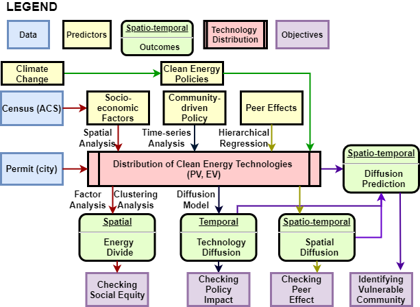

Research Framework

# 1. Social Equity in Clean Energy Policies

## Problem Statement

Clean energy technologies have been introduced and utilized all over the world seeking more reliable and sustainable energy systems in response to climate change. This rapid transition to the new energy system could lead to undesirable impacts on some communities as shown in the case of telecommunication where the digital divide has excluded vulnerable groups of people from knowledge-based societies and economies (Chen and Wellman 2004). In fact, European Union (EU) has already experienced that the uneven deployment of energy poverty and social distribution are correlated in that spatial and social distribution are highly uneven (Bouzarovski and Tirado Herrero 2017). In this context, it is necessary to review how residential PV and EV are spatially distributed with a goal to understand the spatial trends of how clean energy policies and incentives have been implemented. This may help identify issues related to social equity; uneven distribution may indicate particular communities being left out from the recent development of clean energy technologies, particularly those who are more vulnerable to the climate change.

## Literature Review

Energy justice was discussed in terms of access to affordable energy (energy security), fuel poverty (energy vulnerability on distributional unfairness), and politics of energy infrastructure and has been framed further from environmental and climate justice. Energy justice from an inter-disciplinary perspective in energy is a new center of gravity of justice scholars (Jenkins et al. 2016). Furthermore, energy justice has been conceptualized as one of the specific academic fields in energy with the concern of even distribution of costs imposed on communities equally and benefits from the access of the modern energy in addition to procedures of inclusive decision making (Sovacool et al. 2015).

Energy policies have been dealing with only one section of energy system, which require multi- and trans-disciplinary based on practices of integration. ‘Systems’ thinking was suggested including energy’s externalities for transition to low-carbon sources spanning resource mining, transmission, and waste in social, economic, and environmental impacts (Jenkins et al. 2016). Restorative justice was discussed for an application in practice through environmental impact assessment (when the project built), social-license-to-operate (with the local communities over the life-span of the energy infra), and energy financial reserve obligation to ensure the financial capacity to end the energy infrastructure (Heffron and McCauley 2017). They suggested more just energy trilemma: economics, politics (energy security) and environment (climate change mitigation) governed by the energy law and policy (energy justice). Green investment funds could be an example in this energy trilemma.

As a decision-making tool for energy justice, Sovacool et al. (2017) suggested 2 more principles - resistance (standing up to injustice) and intersectionality (intertwined with socioeconomic, political and environmental) - in addition to the previously discussed 8 principles - availability (security of supply), affordability (stable prices), due process (stakeholder participation in policy making process), good governance (with information, accountability, transparency), sustainability (meeting the need of the present without compromising the future generations), intergenerational equity (for present and future generation), intragenerational equity (for different communities access to energy) and responsibility (for environment, climate change, future generation, non-human species).

Bouzarovski and Simcock (2017) addressed the lack of geography for the injustice of energy poverty in terms of spatial justice, the geographical dimensions of inequality and inequity with landscapes of material deprivation (infrastructure and built environment), geographic underpinnings of energy affordability (energy prices and household incomes), vicious cycles of vulnerability (poor health due to material and socioeconomic spatial inequalities) and spaces of misrecognition (recognition injustice by not identifying or ignoring certain groups which affects household practices). They claim energy transitions are generators of geographically uneven social, political and environmental displacements leading to vulnerability of particular groups.

Distributed energy systems have potential to reduce energy poverty (Sovacool et al. 2014). In regard to distribution of energy production, the uneven distribution of production facilities has mainly been discussed in environmental justice while an affordable energy access has been discussed in terms of income equality and low carbon transitions for energy consumption (Fuller and McCauley 2016). Moreover, proper distribution (distributive justice or redistribution) and impartiality in decision-making (procedural justice and empowerment) are interconnected in that energy justice should be the first to consider for consequences to the people the policies are intended to benefit (Sovacool and Dworkin 2015).

Previous studies have found factors or drivers to the diffusion of clean energy technologies such as socioeconomic characteristics, built environment, peer effects, climate, local regulations and policy variables - spatial neighboring effects, built environment, and policy variables (Graziano and Gillingham 2015); higher income, home owners (Keirstead 2007); home ownership and neighborhood effects (Hofierka et al. 2014); owner occupied, single family, suburban and rural, preexisting PV installations (Graziano and Gillingham 2015); less dense population, single family home (Muller and Rode 2013); additional installation in neighborhood, stronger peer effect (Bollinger et al. 2012); Peer effects such as imitation, herd behavior, and social interaction (Scott et al. 2011); transaction cost e.g. time spent on negotiating (Seel et al. 2014); and solar irradiation (Schaffer and Brun 2015).

The previous empirical analyses confirm that currently, there are communities left out from the benefits of clean energy technologies, PV and EV with uneven distribution of costs. This raises an issue on social justice. From the utilitarian perspective, it is more efficient to use the limited resources to maximize the global benefits, thus current distribution of clean energy technologies as a result of the present clean energy policies, seems to get along with this principle as opposed to the social justice. For example, rebates, tax credits, production performance credits, property tax exemptions, and sale tax exemptions are the forms of regressive taxation benefiting wealthier households resulting in taxation on low-income households leading to energy inequalities (Poruschi et al. 2019). Opportunities to take part in the incentives are hard for those who can’t afford clean energy technologies. In this regard, comprehensive, multi-scalar strategic approach spanning the whole energy system was suggested through less regressive means than carbon taxes or flat levies on energy bills (Bouzarovski and Simcock 2017).

## Methodology

While a number of studies have investigated various aspects of the policies designed to support PV system and EV charger installations, there is still a dearth of studies aimed at investigating the impact of such policies on social equity. Two unanswered questions have emerged: (1) were there certain communities inadvertently left out from incentive opportunities? and (2) do those current policies help to encourage the social equity in clean energy technologies? To answer these questions, the study aims to perform a spatial analysis of the distribution of PV and EV charger installed-buildings in terms of built environment and socioeconomic characteristics based on the census tracks of Seattle, WA. In particular, this study aims to explore patterns of the residential (single family and multifamily) housings regarding PV and EV chargers by examining spatial clustering and associations among variables through several data sources. The examined data entails the socioeconomic and built environment characteristics based on the American Community Survey (ACS) of the census.

> - Task 1: Map clean energy technologies (PV and EV) to verify distribution patterns
> - Task 2: Find the latent variables of built environment and socioeconomic characteristics using Factor Analysis
> - Task 3: Verify the suitability of the latent variables to the distribution of PV and EV using clustering analysis
> - Task 4: Find the significant factors to the distribution patterns using spatial regression model
> - Task 5: Find the vulnerable communities to each latent variable using Geographically Weighted Regression (GWR)
> - Task 6: Verify the social equity in the distribution of clean energy technologies.

This study focuses on the City of Seattle open data portal which keeps the records of electrical permits issued between 2003 and 2019 in Seattle. Electrical permits are required when residential houses install PV and EV chargers on their properties. The present study employed advanced data mining techniques to identify residential PV and EV charger installations among the data sets. The data includes geographical coordinates (latitudes and longitudes), dates of the PV and EV charger installations, and PV and EV charger contractors who installed the systems. Mapping the points of residential PV and EV charger allows to verify a certain pattern in the installations.

The expected rates of residential PV and EV charger per each census tract are estimated based on the total number of housing units and their respective residential PV and EV charger numbers. Standardized Installation Ratio (SIR) is defined by $Y_i$, the number of residential PV and EV chargers over $E_i$, the expected number of residential PV and EV chargers given the estimated proportion. In this context, SIR refers to the total number of residential PV and EV charger over the total number of housing units.

$$SIR_i = \frac{Y_i}{E_i}$$

A Moran’s I test identifies the global clustering in the distribution of the rates of residential PV and EV chargers if the test statistic has a very small p-value which confirms that the residential PV and EV charger rates across census tracts are clustered. This clustering trend can be alleviated by fitting a model with appropriate covariates with the similar spatially distributional characteristics. In this context, socioeconomic and built environment characteristics were examined to identify the most proper covariates. Having verified that there is a spatial pattern in the residential PV and EV charger installation rates, there might be related or shared latent variables in the socioeconomic and built environments in the region.

K-means clustering analysis, afterward, identifies similar communities in terms of socioeconomic and housing patterns in the region. It should be noted that K-means clustering does not take into account the PV and EV charger installation rates to define the Euclidean distance among data points, thus the clustered groups are determined only by the latent variables. This will help to see the difference among the clustered groups for PV and EV charger distributions.

A Poisson log-normal spatial model is tested to address any residual clustering issues using a Bayesian method, Integrated Nested Laplace Approximations (INLA), which combines Laplace approximations and numerical integration in a very efficient manner. INLA enables Generalized Linear Mixed Models (GLMMs) to address temporal and spatial error terms. Furthermore, an Intrinsic Conditional Auto-Regressive (ICAR) model addresses spatial autocorrelation.

$$\begin{aligned}
Y_i |\beta_{0},\beta_{1},\beta_{2},\beta_{3},S_i,\epsilon_i & \sim_{ind} \mbox{Poisson}(E_i \mbox{e}^{\beta_{0}+\beta_{1}X_{1i}+\beta_{2}X_{2i}+\beta_{3}X_{3i}} \mbox{e}^{S_i + \epsilon_i}),\\
\epsilon_i | \sigma_\epsilon^{2} & \sim_{iid} \mbox{N}(0,\sigma_\epsilon^{2}),\\
S_1,...,S_n | \sigma_s^{2} & \sim ~~~ \mbox{ICAR}(\sigma_s^{2}).
\end{aligned}$$

Geographically Weighted Regression (GWR) is used to address the local variation of coefficients of predictors by taking into account the local spatial dependency in order to locate regions more sensitive to each predictor.

$$\begin{aligned}
Y(s) = E(s)\mbox{e}^{(\beta_{0}+\beta_{1}(s)X_1(s)+\beta_{2}(s)X_2(s)+\beta_{3}(s)X_3+\epsilon(s))}
\end{aligned}$$

# 2. Policy Impact/Peer Effects on Diffusion (PV and EV)

## Problem Statement

PV distribution patterns can’t be explained only by economic profitability alone such as solar insolation, electricity bill and financial incentives (Karteris and Papadopoulos 2012). There are other drivers affecting the adoption of new technologies. For example, local regulations, education level, home ownership and peer effects also explain the distribution patterns. Financial drivers due to the advent of grid parity and behavioral factors such as social contagion or peer effects were found to be drivers for the diffusion of rooftop solar PV (Curtius et al. 2018). Significant spatial spillover effects were also found between neighboring counties while the differences of economic incentive mainly influenced the spatial and temporal patterns of PV adoption (Dharshing 2016). However, there is still a dearth of studies aimed at investigating the impact of peer effects on diffusion in a quantitative method as mostly surveys have been performed to investigate the significance of peer effects. As a social influence on decision making for the adoption of a new technology is underestimated (Nolan et al. 2008), this study is based on a premise that the diffusion of clean energy technologies is impacted by non-financial factors such as spatial peer effects (SPE) and spillovers. In this regard this study will investigate how peer effects and the local knowledge mobilization affect the diffusion. In particular, spillover effects (social contagion) and local advocacy on diffusion of technologies will be addressed.

## Literature Review

Wolske et al. (2018) discussed about strategies in behavior economics and psychology to increase the financial appeal of PV. They found underlying consumer motivations and predispositions such as perceived social support and consumer innovation are more significant as the primary factors over behavior economics and psychology. As once market is matured, the factors that influence consumer’s decision making shift (Heiskanen and Matschoss 2017) they assumed that if PV market is matured, it is possible that the gain/loss frame, perceived temporal distance and clarity of marketing claims may have stronger influences. Furthermore, importance of perceived social support and peer effects were addressed by highlighting pro-solar opinion leaders, hosting workshops and connecting consumers with PV adopters in the community (Noll et al. 2014). Curtius et al. (2018) stressed out the social influences on the decision to PV adoption through suggesting snowball effects by facilitating the creation of regional hot spots over the shotgun approach of uniform nationwide incentives. Regarding how and why peer effects work on the decision to adopt, descriptive norms was introduced as what people do typically and normally as such people confirm this norm especially under the condition of high uncertainty (Nolan et al. 2008). In addition, injunctive norms are about what people approve related to what is socially expected. They found the number of PV installation as a descriptive norm affected PV installation through social pressure, the mediator or the injunctive norm. A higher number of PV in neighborhood resulted in stronger social pressure, the mediator as well as intentions to install PV.

Peer effects can be discussed by the strength of interpersonal ties and geographical proximity (Curtius et al. 2018). Furthermore, it has temporal aspects as adoption increases with the existence of previous PV (Bollinger and Gillingham 2012). Peer effects and local organisations promoting PV were found to be the most important by identifying local factors to PV diffusion through surveys to PV adopters with comparison with lower diffusion municipalities (Palm 2017). Neighboring effect on diffusion of clean energy technologies could be discussed in terms of peer effects which refer to externalities in which the characteristics or actions of a reference group affect an individual’s behavior or outcomes (Ryan 2017). Peer effects on diffusion of clean energy technologies could be investigated by the spillover effects between neighboring communities or in terms of individual’s surrounding local built environments. Muller and Rode (2013) discussed peer effects based on spatial and temporal distance between installations. Brudermann et al. (2013) found word of mouth and informative meetings were the significant factors to the diffusion.

In particular, PV is normally installed on the rooftop, visibility of PV could affect neighbor’s decision on PV adoption. In this regard, visibility of clean energy technologies could be considered to be passive peer effects while positive word of mouth is categorized as active peer effects. Scott et al. (2011) discussed peer effects in terms of imitation, herd behavior, and social interaction with terms of the active by solar advocacy and the passive by visibility in neighborhood. Both of active and passive peer effects were also found to influence PV adoption in Texas (Rai and Robinson1 2013).

Spatial models offer insights into spatial dynamics of the diffusion of innovations (clean technologies) which helps future policies to enable transition to a low carbon economy that is just, efficient, and effective (Balta-Ozkan et al. 2015). They added that ignoring spatial dependence leads to biased and inconsistent estimate and loss of efficiency. Graziano et al. (2019) addressed spatial peer-effects (SPEs) and spatial spillovers regarding the built environment and jurisdictional boundaries with cross-sectional (OLS), panel (temporal), and spatial models. Spatiotemporal, built environment, socioeconomic variables including SPE by applying spatial factors within 0.5 to 4 miles were analyzed in addition to addressing spatial spillovers using SAR model, a special case of the general spatial durbin model (SDM). They found SPE decays as time passed and distance increased depending on the built environment.

To take advantage of peer effects, Curtius et al. 2018 suggested co-investments with local authorities, PPP, or solarize campaigns. With financial incentives, peer effects will achieve diffusion in the targeted communities as peer effects play an important role in the early adoption stage of S-shaped diffusion curve (Rogers 1962) while not sure in the matured market though.

Clean Energy Transformation Act (CETA) was signed into law by the Governor of Washington in 2019 to remove greenhouse gas emission from electricity supplies by 2045. It plans to eliminate coal power plants by 2025, at least 80% of electricity should be renewable or non-emitting while up to 20% could be alternative compliance option, and finally 100% of electricity should be renewable or non-emitting by 2045. Furthermore, RCW 19.405.120 focuses on low-income energy assistance by requiring utilities in Washington to provide energy assistance funding and programs to low-income households from July, 2021. Furthermore, RCW 19.405 aims at equitable distribution of benefits:

> “..ensure that all customers are benefiting from the transition to clean energy: Through the equitable distribution of energy and non-energy benefits and reduction of burdens to vulnerable populations and highly impacted communities; long-term and short-term public health and environmental benefits and reduction of costs and risks; and energy security and resiliency.” - RCW 19.405.030(8) states

Energy assistance is to reduce energy burden of the customers of utilities including, but not limited to weatherization and ownership in distributed energy resources (RCW 19.405.020(15)). In this regard, Washington State Department of Commerce (DoC) will estimate the demographic characteristics of households and housing characteristics served by energy assistance funding and programs (RCW 19.405.020(3)(a)).

Furthermore, local agencies have been playing the important role. For example, Solarize Northwest is a community-driven, neighborhood group purchase campaign from Spark Northwest (Northwest Sustainable Energy for Economic Development), a 501(c)3 non-profit organization aimed at creating communities of locally-controlled clean energy by solarize campaigns in cooperation with community organizations, solar contractors, utilities, city governments, and solar lenders. Communities take part in the program by attending workshops, getting site assessments, and contracting for installation.

> - January-April 2011 Queen Anne 30 Queen Anne homes for 130 kilowatts
> - July-October 2011 Magnolia 29 Magnolia homes for 114 kilowatts
> - January-April 2012 NE 52 Northeast Seattle homes for 246 kilowatts
> - January-April 2013 NW 141 Northwest Seattle homes for 640 kilowatts
> - July-October 2013 Central/ SE 185 homes for 885 kilowatts
> - July – October 2014 SW 111 homes for 684 kW

## Methodology

Washington State CETA features social justice and assistance to low-income households. It aims at not only equitable distribution of benefits, reduction of burdens to vulnerable communities, but also public health, environmental benefits, and energy resilience. Furthermore, CETA requires that all utilities in the state implement energy assistance funding and programs to low-income households by means of bill reductions and weatherization, energy efficiency, and ownership in distributed energy resources. In this regard, it is necessary to investigate how clean energy policies, programs, or campaigns affect diffusion of clean energy technologies in different communities. In particular, Solarize Northwest campaign impact on diffusion in Seattle will be investigated using time series analysis including interrupted time series (ITS). This analysis will verify the impact of the campaign on communities with respect to diffusion of PV and EV in Seattle. In addition, peer effects on diffusion of clean energy technologies will be investigated to understand how the visibility of PV and EV can influence diffusion of the technologies. The questions are: (1) does the community-driven campaign affect diffusion of PV and EV? and (2) does the passive peer effects of PV visibility affect diffusion in the community?

> - Task 1: Find diffusion trends of clean energy technologies (PV and EV) for each neighborhood over the years
> - Task 2: Indicate the policy interruption (such as incentive campaigns) on the diffusion trends of clean energy technologies
> - Task 3: Analyze the interruption impact of the policy to diffusion using time series models
> - Task 4: Analyze the peer effects of neighboring built environments on diffusion using hierarchical regression models

ITS evaluates the interventions which is appropriate for interventions introduced at a population level over a clearly defined time period and that target the reference population outcomes. This analysis is suitable for a continuous sequence of observations over time with respect to the intervention which differentiates pre-intervention and post-intervention period. The outcome should be available after the intervention and the time intervals should be equally spaced over time. Two models are used for single group and multiple groups. Single group analysis aims at impact of the intervention on diffusion of PV in Seattle while multiple group analysis targets the same goal while employing EV or diffusion trend of PV on other community as a control group to verify the impact of the intervention.

$$\begin{aligned}
Y_t = \beta_{0}+\beta_{1}T_t+\beta_{2}X_t+\beta_{3}T_tX_t+\epsilon_t,
\end{aligned}$$

where, T = the time elapsed since the start of the study; X = a dummy variable indicating the pre‐ or the post‐intervention period ;Y= the outcome at time;$\epsilon$ = estimates the error; $\beta_0$ = estimates the base level of the outcome at the beginning of the series; $\beta_1$ = estimates the base trend; $\beta_2$ = estimates the change in level in the post‐intervention segment; $\beta_3$ = estimates the change in trend in the post‐intervention segment.

$$\begin{aligned}
Y_t = \beta_{0}+\beta_{1}T_t+\beta_{2}X_t+\beta_{3}T_tX_t+\beta_{4}Z+\beta_{5}ZT_t+\beta_{6}ZX_t+\beta_{7}ZT_tX_t+\epsilon_t
\end{aligned}$$

where, Z = dummy variable for group; $\beta_4$ = difference between the groups at the beginning time point; $\beta_5$ = difference between the groups in prior trend; $\beta_6$ = difference between the groups in change in level; $\beta_7$ = difference between the groups in change in trend.

# 3. Identifying Vulnerable Communities with Uneven Distribution in Spatiotemporal Aspects

## Problem Statement

Reliability of energy supply has proven to be important especially during emergency situations when, for example, medical services are in high demand. Furthermore, about 1.1 billion people lack access to electricity and 52 billion USD annual investment is needed for the Sustainable Development Goals (SDGs) (IEA 2017). Lack of electricity affects more vulnerable people such as patients. Hurricane Maria caused additional deaths in Puerto Rico in 2017, especially to those who relied on respirators powered by electricity (Robles et al. 2017). It is known that Maria incurred the longest blackout with more than 100 days in the US history (Irfan 2018). Respiratory patients are more vulnerable to power outages that mortality and respiratory hospital admissions increased significantly during the blackout (Lin et al. 2011). These studies and reports suggest that reliable power supply is essential to those vulnerable communities. To that end, decentralized energy network has potential to improve the energy accessibility, and has been increasing due to efficient end-use appliance and low-cost photovoltaic supported by information and communication technologies (ICT) and virtual financial services (Alstone et al. 2015). However, 1.3 billion people currently lack access to electricity, and experience barriers to mobilize the decentralized energy networks to local level.

While it is known that decentralized energy systems are improving resilience, intermittent power generation of photovoltaic (PV) systems affect reliability of power supply for the community. This increases challenges to the grid system operators. The communities with higher decentralization trends need to address uncertain power production schedule due to the lack of active generation and demand connected. Also, more diverse and less correlated power sources, energy storage and demand participation are necessary. It requires improved forecasting technologies and new operating tools to make sure stability and coordination among transmission systems. In this regard, this study will identify where and which communities will be more socially vulnerable in terms of resilience in coming years by predicting the diffusion trends of clean energy technologies. In addition, as installations of PV systems and EV chargers are expected to increase, this study will also identify technically more vulnerable communities in terms of the different rates of the technology penetrations in the region. It is because higher penetration and uneven distribution of PV and EV lead to interruptions to the local electrical grid.

## Literature Review

Climate change and its impact on urban systems have raised questions of how to improve resilient systems especially related to energy. Previous studies introduced indexes related to resilience for analyses, and created mathematical functions to interpret the current phenomenon and simulated to prove their hypotheses. Energy resilience study is still at its emerging stage that a few literature has tried to define energy resilience. First, the common definition of resilience could be discussed in terms of resilience abilities (preparation, absorption, recovery, and adaptation). It is also addressed in terms of sustainability related dimensions (availability, accessibility, affordability, and acceptability). “Preparation” in resilience ability and “availability” in sustainable dimension are considered to be the most critical to address energy resilience (Sharifi and Yamagata 2016). “Preparation” involves early adoption of planning and design measures to avoid potential disruptions. Preparation measure is known to be the most effective to improve the resilience. Furthermore, reserve margins, diverse energy sources, and monitoring systems could improve “availability” of energy services.

Vulnerability could be defined as being at risk of having limited capacity of power to protect one’s interest. Vulnerability is also mainly interpreted in connection with weakness, dependency, powerlessness, deficiency, and passivity. This implicit bias leads to a problem in ethical response as it entails negative connotation (Gilson 2013). Vulnerability could be interpreted in two sources - “inherent” and “situational” (Mackenzie 2013). Our neediness and dependence on others incur inherent vulnerability. This applies to energy dependency in the modern society because energy is essential to the basic human needs to sustain life. Situational vulnerability is context dependent such that negative impact of energy poverty on a certain community, would be different from the impact on other communities, depending upon social, political, economic, and environmental situations. For example, effects of a same hurricane would be less in a community, which has more resilient energy systems. Thus, it is necessary to discuss characteristics of resilient energy systems in terms of energy dependency and situational conditions (social, political, economic, and environmental).

Community resilience could benefit from integrated energy diversity and decentralization in terms of reliable energy supply. Two emerging characteristics for energy resilience were presented: integrated energy system (IES) and distributed energy resources (DERs) (Lin and Bie 2016). IES is related to interdependence and diversity of systems while DERs represent energy sources spread across regions. Integration of interdependent infrastructures including, but not limited to energy, water, and telecommunication, also bring out the better mitigation in response to extreme weather (Zimmerman et al. 2017). DERs could be interpreted as decentralized energy systems such as micro-grids. They found that When systems were combined, the complexity became characterized and the emergent behavior of the system was hard to be expected. In the study, two measures for energy resilience were introduced: hardware hardening and operational resilience strategies. Hardware hardening happens to be costly and influences only a limited part of the whole system that is less effective. On the other hand, increasing diversity of energy supply, would increase the system resilience.

Understanding inter-dependencies of infrastructures are essential to address vulnerability. For instance, a study shows that inter dependencies in infrastructures including energy, are important to a system resilience, and space and time are critical to assess hazard impact of interdependent lifeline infrastructures (Wang and Reed 2017). Furthermore, the study suggested that micro-grid at the community level, would increase robustness of the energy system in addition to hardening structure of power delivery components and increasing power generation redundancy. This study argues that social science involvement may be necessary to investigate from the community perspectives in addition to the infrastructure operators’ perspectives.

Homogeneous and a sole energy production system not only adversely affects communities due to the lack of diverse energy supply, but also harms the social and environmental value of the built environment. Decentralization of energy production and supply has played an important role to resilient community as it is more robust in response to disruptions. For example, Shahidehpour et al. (2017) shows controllable and islandable micro-grid systems (decentralized systems) would improve the resiliency of power grids in extreme conditions. On the other hand, centralized energy production may have contributed to vulnerability of the current urban form as most of subsystems of human activities are relying on the sole energy production. In this regard, the more dependent to a sole energy production, the more vulnerable a system would face interruptions.

Energy transition for decarbonization due to climate change requires demand side participation, battery storage, and decentralization with respect to variable renewables considering cost-reliability tradeoff. Without consideration of the cost-reliability tradeoff, going 100% renewable would end up with high cost and low reliability due to the characteristics of variability of renewables. For example, higher uptake of PV is a challenge to network operator to keep enough capacity and voltage (Balta-Ozkan et al. 2015). This reliability issues in supply-demand balance result from the fact that renewables do not have active generation and demand connected. This affects energy planning and operation. Energy planning is related to resource adequacy to ensure the demands of system, local and flexible capacity are met. Power plants get paid by providing those capacities. As more distributed power sources are increasing, more diverse and less correlated power sources, storage and demand participation are needed. While adequacy is a planning challenge, flexibility and the provision of energy services are an operational challenge which requires probabilistic mindset, distributed energy storage, data analytics and coordination between systems. Furthermore, with respect to market, price volatility due to variable renewables requires investment for flexibility. In addition, voltage and frequency control should be paid attention as renewables are non-synchronous with no inherent inertial response in that change in the synchronous nature of the electricity system will affect the core technology of the current power infrastructure with its control and protection.

DER adopter analysis per technologies (PV, EV, and HVAC) and aggregating scales were discussed by comparison of distribution patterns per technologies and aggregating scales (Heymann et al. 2019). They suggested electricity network planning to consider uneven distribution for investment plan with respect to EV and PV with different distribution patterns. They argued that the difference of EV and PV adoption for energy policy design in consideration of synergies and distributional justice should be implemented as it Will help to design DER support schemes for maximizing penetration and reducing network expansion costs.

Deregulation may lead to less grid reliability with increased competition, which suspended some state to have the market restructuring or deregulation (Michaud 2018). Likewise, increasing renewables in the grid affects the grid reliability as well with an issue on hosting capacity. Hosting capacity is the amount of distributed PV (DPV) that can be added to distribution system before control changes or system upgrades are required to safely and reliably integrate additional DPV. Factors influencing the hosting capacity is the characteristics of the DPV system, such as whether advanced inverter settings are utilized, the system size, and where it is located on the circuit. It includes the location and time-varying behavior of all distributed energy resources and the existing equipment on a circuit. As the system configuration evolves over time depending on investments made by utilities, DPV owners or developers, distribution planning practices are important such as when upgrades or other mitigation are required (Dubey et al. 2015).

Furthermore, due to the increase of PV, EV, and electric heating, overloading will occur on the medium voltage grid (Sijm 2014). PV self-consumption will lower medium voltage distribution grid losses and investments in cables and transformers (Litjens et al. 2018). In this regard, higher level of PV self-consumption may decrease stress on the grid thus easier integration of PV in the existing infrastructure (van der Kam and van Sark 2015). This study suggested self-consumption by energy storage and demand side management (DSM). They discussed about the establishment of the geographical misfit between EV and PV diffusion and the impact on energy systems. They found out that EV diffusion lags behind PV diffusion led to different supply and demand patterns for different regions which require different grid architectures.

## Methodology

Installations of PV systems and EV chargers are expected to increase, which leads to interruptions to the local electrical grid. To that end, it is important to identify vulnerable communities in terms of rates of the technology penetrations in different communities. The questions are: (1) what would be the trends of diffusion of PV and EV in each community? and (2) where are the communities that the stakeholders such as policy makers and local system operators should pay attention with respect to the rapid increases of PV and EV? For these questions, this study aims to conduct machine learning techniques to predict diffusion of clean energy technologies in consideration of socioeconomic, built environment features, policy intervention and peer effects. The predicted diffusion will be matched with target communities as a way to identify socially and technically vulnerable communities in terms of diffusion of clean energy technologies.

> - Task 1: Verify the importance of identifying communities with higher decentralization trend
> - Task 2: Identify methods to best predict the diffusion of clean energy technologies in consideration of the identified significant factors: socioeconomic, built environment characteristics, policy intervention, and peer effects
> - Task 3: Develop a robust prediction model to identify vulnerable communities with regards to clean energy technology distribution
> - Task 4: Validate the prediction model in case studies and evaluate the impact of the different diffusion rates of the clean energy technologies on the communities

Using the features such as socioeconomic and built environment characteristics, peer effects, and policy intervention, a prediction model will be constructed with respect to a linear regression with Ridge, Lasso, and Elastic net regression models. Regularization is necessary to avoid overfitting which leads to higher variation when applying the model to other data sets. It is bias-variance tradeoff that a localized model is hard to be generalizable. Regularization helps to avoid overfitting by adding penalty term to the loss function. A penalty term prevents model parameters (feature weights) from becoming larger. The best model could be identified in terms of accuracy and root square mean error (RSME).

There are several machine learning algorithms. For example, a support vector machine (SVM) separates data using a hyper-plane which is defined by support vectors or the nearest observations. Depending on the tolerance of margin violations, there are soft and hard margin classifications. An SVM regressor with Gaussian radial basis function (RBF) kernel is a special form of SVM that has higher dimensional feature vectors added by Gaussian RBF. There are several kernels such as polynomial and sigmoid. The benefit of kernel is that the classifier can be flexible enough to separate data without involving additional features. A random forest model features entailing randomness when training a model that helps promoting diversity leading to a better model performance. This algorithm is an ensembles of decision trees that try to separate data into homogeneous groups by setting thresholds. Extra-trees even randomize the thresholds to have a more diversity environment for the model get trained. A gradient boosting model fits data then keeps fitting the residuals in sequence by adding predictors. These algorithms have several hyper-parameters that could be searched for the best model performances by using modules such as randomizedSearchCV and gridsearchcv. All the models could be fitted with the optimal hyper-parameters found.

Gradient descent is a generic optimization algorithm in machine learning. For example, to minimize a cost function $f(\theta)$, we start with an arbitrary point $\theta^{0}$ and repeat the algorithm until it is near the optimal point. The cost function could be various depending upon the context. The goal is the find the weights ($\theta$) which minimize the cost function.

$$\begin{aligned}
\theta^{k + 1} = \theta^{k} - \eta_k\nabla f(\theta^{k})
\end{aligned}$$

where, $\nabla f(\theta^{k})$ = the direction of steepest descent of f at a point $\theta$; $\eta_k$ = “step size” or “learning rate.” $\theta^{k+1}$ has a better value than $\theta^{k}$. With each step of Gradient descent, the value function gets better. Eventually, the algorithm converges to a local minimum.

# Significance of Research and Contribution to Knowledge

This diffusion study in clean energy technologies is significant to both of energy policy analysis and electricity network planning as it involves with social justice and urban planning. Due to incentives, uneven distribution leads to a redistribution of income mainly benefiting communities with favorable factors such as geographic conditions (Dharshing 2017). In addition, those incentives such as Feed-in Tariffs (FiTs) are the forms of regressive taxation benefit wealthier households resulting in taxation on low-income households leading to energy inequalities (Poruschi et al. 2019). Furthermore, multi-family houses and renter-occupied units which are common in the urban regions lack those incentives (Gillingham et al. 2012). The benefits and costs of diffusion of the clean energy technologies are currently unevenly distributed questioning the energy justice.

There are several studies concerning about the social equity in the distribution of clean energy technologies. To address imbalances in PV adoption, Dharshing (2017) suggested policies to take local-specific measures. Leasing business was recommended for less affluent households such as renters to join in the PV market (Drury et al. 2012) and community solar (Funkhouser 2015). Wustenhagen et al. (2007) emphasized the local acceptance of renewables and the community ownership to increase PV adoption. Furthermore, concerning resilient energy systems, governance of energy infrastructures in connection with polycentric governance will promote resilient energy systems (Goldthau 2014). It is because polycentric governance promotes decentralized energy systems. Social science would be helpful to provide the reliable energy services as polycentric governance is critically related to socioeconomic actors.

In this context, these studies will perform the empirical analyses of residential PV and EV chargers in Seattle, WA, to verify that (1) there is a clustered pattern in the distribution of the clean energy technology installations, (2) socioeconomic and built environment characteristics explain the uneven distribution, and (3) some neighbors are more sensitive to the identified factors in terms of installations. Furthermore, peer effects and policy interventions will be verified whether they significantly influence the diffusion trend in a spatio-temporal way. A diffusion model will be suggested on PV and EV adoption in Seattle. This will confirm the importance of community involvement and peer effects on diffusion of clean energy technologies. In addition, the expected vulnerable communities due to the uneven diffusion rates of PV and EV will be identified. A prediction model will be suggested to estimate the future impact of addition of clean energy technologies such as PV and EV on the communities.

The study results will reveal social equity issues based on the uneven distribution of benefits and costs of clean energy technologies, i.e., certain communities are underserved. This is because incentives such as tax credits and FiTs are the forms of regressive taxation passing on the costs of enhancement and maintenance of energy infrastructure required to add more renewables to the underserved communities through taxes and increasing electric bills. Clean energy technologies play a role in community resilience because decentralized energy systems such as residential PV are more resilient in response to climate change. Therefore, higher diffusion of the clean energy technologies helps communities equipped with better resilience in addition to economical, health and environmental benefits. However, this entails burden to the grid due to the characteristics of the variable power generation. System operators are required to have improved forecasting, new operating tools ensuring stability and coordination between systems. In this regard, peer effects and policy interventions verified by the studies will predict the future impact of the technology adoptions socially and technically on the local communities. This will help policy makers to better support any underserved communities under limited resources (e.g., those who rent houses and have less finance for PV and EV) by devising equitable policies in response to climate change. Policy makers and system operators can refer to the results to plan their investment on energy distribution systems and scalable renewable energy infrastructures for vulnerable communities.

Self-sufficient energy system or decentralized energy production has increased the resilience of human societies and communities. So has done energy diversity, which is compared to the biological diversity keeping ecosystem healthy and stable. Diversification effect lessens the volatility or risk by having less correlated characteristics as a whole leading to a healthy society. Likewise, energy diversity, in the context of diverse energy sources, would reduce the risk of human society, thus enhance the stability of the built environment. Decentralized and diversified energy systems would enhance the community resilience in terms of vulnerability and resilience in response to climate change.

# Reference

- Ajaz, W. (2019). “Resilience, environmental concern, or energy democracy? A panel data analysis of microgrid adoption in the United States.” Energy Research & Social Science, 49, 26–35.
- Araújo, K., Boucher, J. L., and Aphale, O. (2019). “A clean energy assessment of early adopters in electric vehicle and solar photovoltaic technology: Geospatial, political and socio-demographic trends in New York.” Journal of Cleaner Production, 216, 99–116.
- Augustine, P., and McGavisk, E. (2016). “The next big thing in renewable energy: Shared solar.” The Electricity Journal, 29(4), 36–42.
- Baba, H., and Asami, Y. (2017). “Regional Differences in the Socio-economic and Built-environment Factors of Vacant House Ratio as a Key Indicator for Spatial Urban Shrinkage.” Urban and Regional Planning Review, 4(0), 251–267.
- Balta-Ozkan, N., Yildirim, J., and Connor, P. M. (2015). “Regional distribution of photovoltaic deployment in the UK and its determinants: A spatial econometric approach.” Energy Economics, 51, 417–429.
- Bollinger, B., and Gillingham, K. (2012). “Peer Effects in the Diffusion of Solar Photovoltaic Panels.” Marketing Science, INFORMS, 31(6), 900–912.
- Bouzarovski, S., and Simcock, N. (2017). “Spatializing energy justice.” Energy Policy, 107, 640–648.
- Bouzarovski, S., and Tirado Herrero, S. (2017). “The energy divide: Integrating energy transitions, regional inequalities and poverty trends in the European Union.” European Urban and Regional Studies, 24(1), 69–86.
- Brown, A. C. (2016). “The value of solar writ large: A modest proposal for applying ‘value of solar’ analysis and principles to the entire electricity market.” The Electricity Journal, 29(9), 27–30.
- Brudermann, T., Reinsberger, K., Orthofer, A., Kislinger, M., and Posch, A. (2013). “Photovoltaics in agriculture: A case study on decision making of farmers.” Energy Policy, 61, 96–103.
- Chan, G., Evans, I., Grimley, M., Ihde, B., and Mazumder, P. (2017). “Design choices and equity implications of community shared solar.” The Electricity Journal, 30(9), 37–41.
- Chen, W., and Wellman, B. (2004). “THE GLOBAL DIGITAL DIVIDE – WITHIN AND BETWEEN COUNTRIES.” (7), 8.
- Curtius, H. C., Hille, S. L., Berger, C., Hahnel, U. J. J., and Wüstenhagen, R. (2018). “Shotgun or snowball approach? Accelerating the diffusion of rooftop solar photovoltaics through peer effects and social norms.” Energy Policy, 118, 596–602.
- Dharshing, S. (2017). “Household dynamics of technology adoption: A spatial econometric analysis of residential solar photovoltaic (PV) systems in Germany.” Energy Research & Social Science, 23, 113–124.
- “Diffusion of innovations. BY Everett M. Rogers. The Free Press of Glencoe Division of The Macmillan Co., 60 Fifth Avenue, New York 11, N. Y., 1962. xiii + 367 pp. 14 × 21 cm. Price $6.50.” (1963). Journal of Pharmaceutical Sciences, 52(6), 612–612.
- Drury, E., Miller, M., Macal, C. M., Graziano, D. J., Heimiller, D., Ozik, J., and Perry IV, T. D. (2012). “The transformation of southern California’s residential photovoltaics market through third-party ownership.” Energy Policy, 42, 681–690.
- Dubey, A., Santoso, S., and Maitra, A. (2015). “Understanding photovoltaic hosting capacity of distribution circuits.” 2015 IEEE Power Energy Society General Meeting, 1–5.
- Fuller, S., and McCauley, D. (2016). “Framing energy justice: perspectives from activism and advocacy.” Energy Research & Social Science, 11, 1–8.
- Funkhouser, E., Blackburn, G., Magee, C., and Rai, V. (2015). “Business model innovations for deploying distributed generation: The emerging landscape of community solar in the U.S.” Energy Research & Social Science, 10, 90–101.
- Gillingham, K., Harding, M., and Rapson, D. (2012). “Split Incentives in Residential Energy Consumption.” The Energy Journal, International Association for Energy Economics, 33(2), 37–62.
- Gilson, E. (2013). “The Ethics of Vulnerability | A Feminist Analysis of Social Life and Practice | Taylor & Francis Group.” https://www.taylorfrancis.com/books/9780203078136 (Jun. 13, 2019).
- Goldthau, A. (2014). “Rethinking the governance of energy infrastructure: Scale, decentralization and polycentrism.” Energy Research & Social Science, 1, 134–140.
- Graziano, M., Fiaschetti, M., and Atkinson-Palombo, C. (2019). “Peer effects in the adoption of solar energy technologies in the United States: An urban case study.” Energy Research & Social Science, 48, 75–84.
- Graziano, M., and Gillingham, K. (2015). “Spatial patterns of solar photovoltaic system adoption: The influence of neighbors and the built environment.” Journal of Economic Geography, Oxford Academic, 15(4), 815–839.
- Heffron, R. J., and McCauley, D. (2017). “The concept of energy justice across the disciplines.” Energy Policy, 105, 658–667.
- Heiskanen, E., and Matschoss, K. (2017). “Understanding the uneven diffusion of building-scale renewable energy systems: A review of household, local and country level factors in diverse European countries.” Renewable and Sustainable Energy Reviews, 75, 580–591.
- Heymann, F., Lopes, M., vom Scheidt, F., Silva, J. M., Duenas, P., Soares, F. J., and Miranda, V. (2019). “DER adopter analysis using spatial autocorrelation and information gain ratio under different census-data aggregation levels.” IET Renewable Power Generation.
- Hirsch, A., Parag, Y., and Guerrero, J. (2018). “Microgrids: A review of technologies, key drivers, and outstanding issues.” Renewable and Sustainable Energy Reviews, 90, 402–411.
- Hofierka, J., Kaňuk, J., and Gallay, M. (2014). “The Spatial Distribution of Photovoltaic Power Plants in Relation to Solar Resource Potential: The Case of the Czech Republic and Slovakia.” Moravian Geographical Reports, Sciendo, 22(2), 26–33.
- Irfan, U. (2018). “Puerto Rico and the US Virgin Islands are in the longest blackout in US history - Vox.” https://www.vox.com/energy-and-environment/2017/10/30/16560212/puerto-rico-longest-blackout-in-us-history-hurricane-maria-grid-electricity (May 25, 2018).
- Jean, N., Burke, M., Xie, M., Davis, W. M., Lobell, D. B., and Ermon, S. (2016). “Combining satellite imagery and machine learning to predict poverty.” Science, 353(6301), 790–794.
- Jenkins, K., McCauley, D., Heffron, R., Stephan, H., and Rehner, R. (2016). “Energy justice: A conceptual review.” Energy Research & Social Science, 11, 174–182.
- van der Kam, M. J., Meelen, A. A. H., van Sark, W. G. J. H. M., and Alkemade, F. (2018). “Diffusion of solar photovoltaic systems and electric vehicles among Dutch consumers: Implications for the energy transition.” Energy Research & Social Science, 46, 68–85.
- van der Kam, M., and van Sark, W. (2015). “Smart charging of electric vehicles with photovoltaic power and vehicle-to-grid technology in a microgrid; a case study.” Applied Energy, 152, 20–30.
- Karteris, M., and Papadopoulos, A. M. (2012). “Residential photovoltaic systems in Greece and in other European countries: a comparison and an overview.” Advances in Building Energy Research, Taylor & Francis, 6(1), 141–158.
- Keirstead, J. (2007). “Behavioural responses to photovoltaic systems in the UK domestic sector.” Energy Policy, 35(8), 4128–4141.
- Lee, M., Hong, T., Jeong, J., and Jeong, K. (2018). “Development of a rooftop solar photovoltaic rating system considering the technical and economic suitability criteria at the building level.” Energy, 160, 213–224.
- Lin, S., Fletcher, B. A., Luo, M., Chinery, R., and Hwang, S.-A. (2011). “Health Impact in New York City During the Northeastern Blackout of 2003.” Public Health Reports, 126(3), 384–393.
- Lin, Y., and Bie, Z. (2016). “Study on the Resilience of the Integrated Energy System.” Energy Procedia, 103, 171–176.
- Litjens, G. B. M. A., Kausika, B. B., Worrell, E., and van Sark, W. G. J. H. M. (2018). “A spatio-temporal city-scale assessment of residential photovoltaic power integration scenarios.” Solar Energy, 174, 1185–1197.
- Lukanov, B. R., and Krieger, E. M. (2019). “Distributed solar and environmental justice: Exploring the demographic and socio-economic trends of residential PV adoption in California.” Energy Policy, 134, 110935.
- Mackenzie, C. (2013). “Vulnerability: New Essays in Ethics and Feminist Philosophy - Google Books.” https://books.google.com/books?hl=en&lr=&id=6W9MAQAAQBAJ&oi=fnd&pg=PP1&dq=vulnerability+ethics&ots=CybV1ADLth&sig=fCvM7G6Oy-pW32O-Hkp3_22uhPw#v=onepage&q=vulnerability%20ethics&f=false (Jun. 13, 2019).
- Mah, D. N., Wang, G., Lo, K., Leung, M. K. H., Hills, P., and Lo, A. Y. (2018). “Barriers and policy enablers for solar photovoltaics (PV) in cities: Perspectives of potential adopters in Hong Kong.” Renewable and Sustainable Energy Reviews, 92, 921–936.
- Martinopoulos, G., and Tsalikis, G. (2018). “Diffusion and adoption of solar energy conversion systems – The case of Greece.” Energy, 144, 800–807.
- Michaud, G. (2018). “Deploying solar energy with community choice aggregation: A carbon fee model.” The Electricity Journal, 31(10), 32–38.
- Muchunku, C., Ulsrud, K., Palit, D., and Jonker‐Klunne, W. (2018). “Diffusion of solar PV in East Africa: What can be learned from private sector delivery models?” WIREs Energy and Environment, 7(3).
- Müller, S., and Rode, J. (2013). “The adoption of photovoltaic systems in Wiesbaden, Germany.” Economics of Innovation and New Technology, Routledge, 22(5), 519–535.
- Nolan, J. M., Schultz, P. W., Cialdini, R. B., Goldstein, N. J., and Griskevicius, V. (2008). “Normative Social Influence is Underdetected.” Personality and Social Psychology Bulletin, SAGE Publications Inc, 34(7), 913–923.
- Noll, D., Dawes, C., and Rai, V. (2014). “Solar Community Organizations and active peer effects in the adoption of residential PV.” Energy Policy, 67, 330–343.
- Palm, A. (2016). “Local factors driving the diffusion of solar photovoltaics in Sweden: A case study of five municipalities in an early market.” Energy Research & Social Science, 14, 1–12.
- Poruschi, L., and Ambrey, C. L. (2019). “Energy justice, the built environment, and solar photovoltaic (PV) energy transitions in urban Australia: A dynamic panel data analysis.” Energy Research & Social Science, 48, 22–32.
- Rai, V., and Robinson, S. A. (2013). “Effective information channels for reducing costs of environmentally- friendly technologies: evidence from residential PV markets.” Environmental Research Letters, 8(1), 014044.
- Robles, F., Davis, K., Fink, S., and Almukhtar, S. (2017). “Official Toll in Puerto Rico: 64. Actual Deaths May Be 1,052.” The New York Times.
- Sánchez-Lozano, J. M., Teruel-Solano, J., Soto-Elvira, P. L., and Socorro García-Cascales, M. (2013). “Geographical Information Systems (GIS) and Multi-Criteria Decision Making (MCDM) methods for the evaluation of solar farms locations: Case study in south-eastern Spain.” Renewable and Sustainable Energy Reviews, 24, 544–556.
- Schaffer, A. J., and Brun, S. (2015). “Beyond the sun—Socioeconomic drivers of the adoption of small-scale photovoltaic installations in Germany.” Energy Research & Social Science, 10, 220–227.
- Scott, J., and Carrington, P. J. (2011). The SAGE Handbook of Social Network Analysis. SAGE Publications, London, UNITED KINGDOM.
- Seel, J., Barbose, G. L., and Wiser, R. H. (2014). “An analysis of residential PV system price differences between the United States and Germany.” Energy Policy, 69, 216–226.
- Shahidehpour, M., liu, xindong, Li, Z., and Cao, Y. (2017). “Microgrids for Enhancing the Power Grid Resilience in Extreme Conditions.” IEEE Transactions on Smart Grid, 1–1.
- Shang, L., Lee, H. W., Dermisi, S., and Choe, Y. (2020). “Impact of energy benchmarking and disclosure policy on office buildings.” Journal of Cleaner Production, 250, 119500.
- Sharifi, A., and Yamagata, Y. (2016). “Principles and criteria for assessing urban energy resilience: A literature review.” Renewable and Sustainable Energy Reviews, 60, 1654–1677.
- Sijm, J. P. M. (n.d.). “Cost and revenue related impacts of integrating electricity from variable renewable energy into the power system - A review of recent literature.” 52.
- Sovacool, B. K., Burke, M., Baker, L., Kotikalapudi, C. K., and Wlokas, H. (2017). “New frontiers and conceptual frameworks for energy justice.” Energy Policy, 105, 677–691.
- Sovacool, B. K., and Dworkin, M. H. (2015). “Energy justice: Conceptual insights and practical applications.” Applied Energy, 142, 435–444.
- Strupeit, L., and Palm, A. (2016). “Overcoming barriers to renewable energy diffusion: business models for customer-sited solar photovoltaics in Japan, Germany and the United States.” Journal of Cleaner Production, 123, 124–136.
- Vithayasrichareon, P., Mills, G., and MacGill, I. F. (2015). “Impact of Electric Vehicles and Solar PV on Future Generation Portfolio Investment.” IEEE Transactions on Sustainable Energy, 6(3), 899–908.
- Walter, R., Evans, A., and Atherwood, S. (2016). “Addressing the Affordable Housing Crisis for Vulnerable Renters: Insights From Broward County on an Affordable Housing Acquisition Tool.” Housing Policy Debate, 26(1), 123–149.
- Walter, R. J., and Li, Y. (2014). “Moving to Opportunity? An Examination of Housing Choice Vouchers on Urban Poverty Deconcentration in South Florida.”
- Wang, R., Walter, R. J., Arafat, A. A., Ding, X., and Naji, A. A. (2017). “Examining Neighborhood Opportunity and Locational Outcomes for Housing Choice Voucher Recipients: A Comparative Study between Duval County, Florida, and Bexar County, Texas: EXAMINING NEIGHBORHOOD OPPORTUNITY.” City & Community, 16(4), 421–446.
- Wang, S., and Reed, D. A. (2017). “Vulnerability and Robustness of Civil Infrastructure Systems to Hurricanes.” Frontiers in Built Environment, 3.
- Wolske, K. S., Todd, A., Rossol, M., McCall, J., and Sigrin, B. (2018). “Accelerating demand for residential solar photovoltaics: Can simple framing strategies increase consumer interest?” Global Environmental Change, 53, 68–77.
- Wüstenhagen, R., Wolsink, M., and Bürer, M. J. (2007). “Social acceptance of renewable energy innovation: An introduction to the concept.” Energy Policy, 35(5), 2683–2691.
- Xu, Y., Fu, C., Kennedy, E., Jiang, S., and Owusu-Agyemang, S. (2018). “The impact of street lights on spatial-temporal patterns of crime in Detroit, Michigan.” Cities, 79, 45–52.
- Yamagata, Y., Murakami, D., Minami, K., Arizumi, N., Kuroda, S., Tanjo, T., and Maruyama, H. (2016). “Electricity Self-Sufficient Community Clustering for Energy Resilience.” Energies, 9(7), 543.
- Zimmerman, R., Zhu, Q., de Leon, F., and Guo, Z. (2017). “Conceptual modeling framework to integrate resilient and interdependent infrastructure in extreme weather.” Journal of Infrastructure Systems, 23(4), 04017034.